# Covid-19 prediction UK

Kevin Hon Yin Hau

18/03/2020

```r
library(knitr)
knitr::opts_chunk$set(echo = TRUE)
```

For most update news in UK, please visit https://coronavirus.data.gov.uk/

# Covid-19 Total Cases prediction

Update on

```r
Sys.time()
```

```
## [1] "2020-07-24 23:07:56 BST"
```

### Library

```r
library(ggplot2)
library(stringi)
library(dplyr)
# if xlsx format
library(openxlsx)
library(janitor)
```

## Data

File format and structure keeps changing, and it might need to change for different day

```r
# file name

#xlFile <- paste0("COVID-19-geographic-disbtribution-worldwide-",Sys.Date(),".xls")
#DF <- read_xls(paste0("C:\\Users\\",Sys.getenv("username"),"\\Downloads\\",xlFile))
DF <- openxlsx::read.xlsx(paste0("https://www.ecdc.europa.eu/sites/default/files/documents/COVID-19-geographic-disbtribution-worldwide-",Sys.Date(),".xlsx"))

names(DF)[c(1,5:7,11)] <- c('DateRep','NewConfCases','NewDeaths','CountryExp','x')
DF$CountryExp <- stri_trans_general(gsub("_"," ", DF$CountryExp), id = "Title")
#DF$DateRep <- as.Date(as.character(DF$DateRep), "%d/%m/%Y")
DF$DateRep <- janitor::excel_numeric_to_date(DF$DateRep)
```

## Statistics by Country

```r
DF_New <- DF %>% inner_join(DF %>% group_by(CountryExp) %>% summarise(DateRep=max(DateRep))) %>%
  select(CountryExp,NewConfCases,NewDeaths) %>%
  arrange(desc(NewConfCases))
DF_Stat <- DF %>%
  group_by(CountryExp) %>%
  summarise(Total=sum(NewConfCases, na.rm=T),
            Death=sum(NewDeaths, na.rm=T)) %>%
  left_join(DF_New) %>%
  arrange(desc(NewDeaths))
kable(rbind(data.frame(CountryExp="Overall",
                       DF_Stat %>%
                         summarise(Total=sum(Total),
                                  Death=sum(Death),
                                  NewConfCases=sum(NewConfCases, na.rm=TRUE),
                                  NewDeaths=sum(NewDeaths, na.rm=TRUE))),
                                  DF_Stat %>%
              filter(Total>20000)),
      caption="Statistics around the world with total cases > 20000")
```

Statistics around the world with total cases > 20000

| CountryExp | Total | Death | NewConfCases | NewDeaths |
| --- | --- | --- | --- | --- |
| Overall | 15477472 | 633122 | 275925 | 9841 |
| Peru | 371096 | 17654 | 4546 | 3887 |
| Brazil | 2287475 | 84082 | 59961 | 1311 |
| United States Of America | 4034102 | 144242 | 63196 | 1052 |
| India | 1287945 | 30601 | 49310 | 740 |
| Mexico | 370712 | 41908 | 8438 | 718 |
| Colombia | 226373 | 7688 | 7945 | 315 |
| Iran | 284034 | 15074 | 2621 | 221 |
| South Africa | 408052 | 6093 | 13104 | 153 |
| Russia | 795038 | 12892 | 5848 | 147 |
| Indonesia | 93657 | 4576 | 1906 | 117 |
| Chile | 338759 | 8838 | 2357 | 116 |
| Argentina | 141887 | 2617 | 5782 | 111 |
| Iraq | 102226 | 4122 | 2361 | 80 |
| Bolivia | 65252 | 2407 | 1117 | 79 |
| Guatemala | 42192 | 1632 | 1057 | 59 |
| Pakistan | 270400 | 5763 | 1209 | 54 |
| United Kingdom | 297146 | 45554 | 769 | 53 |
| Bangladesh | 216110 | 2801 | 2856 | 50 |
| Kyrgyzstan | 31247 | 1211 | 921 | 42 |
| Egypt | 90413 | 4480 | 668 | 40 |
| Saudi Arabia | 260394 | 2635 | 2238 | 34 |
| Panama | 56817 | 1209 | 911 | 29 |
| Philippines | 74390 | 1871 | 2121 | 28 |
| Romania | 41275 | 2126 | 1112 | 25 |
| Ecuador | 78148 | 5439 | 891 | 21 |
| Nigeria | 38948 | 833 | 604 | 20 |
| Ukraine | 62823 | 1571 | 972 | 20 |
| Turkey | 223315 | 5563 | 913 | 18 |
| Algeria | 25484 | 1124 | 612 | 13 |
| Israel | 57982 | 442 | 1897 | 12 |
| France | 179398 | 30182 | 1062 | 10 |
| Germany | 204183 | 9111 | 815 | 10 |
| Italy | 245338 | 35092 | 306 | 10 |
| Ireland | 25826 | 1763 | 7 | 9 |
| Poland | 41580 | 1651 | 418 | 9 |
| Serbia | 22443 | 508 | 412 | 9 |
| Sweden | 78763 | 5676 | 259 | 9 |
| Moldova | 22105 | 719 | 307 | 7 |
| Azerbaijan | 28980 | 391 | 347 | 6 |
| Belarus | 66688 | 519 | 167 | 6 |
| Oman | 72646 | 355 | 1099 | 6 |
| Honduras | 36902 | 1011 | 800 | 5 |
| Armenia | 36613 | 692 | 451 | 4 |
| Bahrain | 37996 | 134 | 359 | 4 |
| Belgium | 64754 | 9812 | 220 | 4 |
| Canada | 112659 | 8874 | 432 | 4 |
| Kuwait | 61872 | 421 | 687 | 4 |
| Portugal | 49379 | 1705 | 229 | 3 |
| Spain | 270166 | 28429 | 2615 | 3 |
| Japan | 27956 | 992 | 927 | 2 |
| China | 86045 | 4649 | 139 | 1 |
| Dominican Republic | 57615 | 1006 | 1572 | 1 |
| Qatar | 108244 | 164 | 373 | 1 |
| Switzerland | 33913 | 1693 | 117 | 1 |
| Afghanistan | 35928 | 1211 | 13 | 0 |
| Austria | 20148 | 711 | 110 | 0 |
| Ghana | 29672 | 153 | 0 | 0 |
| Kazakhstan | 78486 | 585 | 1687 | 0 |
| Netherlands | 52404 | 6139 | 163 | 0 |
| Singapore | 49098 | 27 | 354 | 0 |
| United Arab Emirates | 57988 | 342 | 254 | 0 |

## For some countries over 50k cases (not include USA)

```r
num <- 50000

Country_num <- DF_Stat %>%
  group_by(CountryExp) %>%
  summarise(Total=sum(Total)) %>%
  filter(Total>num) %>%
  arrange(Total) %>%
  select(CountryExp)

DF_num <- DF %>%
  inner_join(Country_num) %>%
  arrange(CountryExp, DateRep) %>%
  group_by(CountryExp) %>%
  mutate(Total = cumsum(NewConfCases), TotalDeath = cumsum(NewDeaths)) %>%
  filter(Total >= 10000 & CountryExp != "United States Of America") %>%
  mutate(Day = 1:n()) %>%
  select(CountryExp, DateRep, Day, Total, TotalDeath)
```

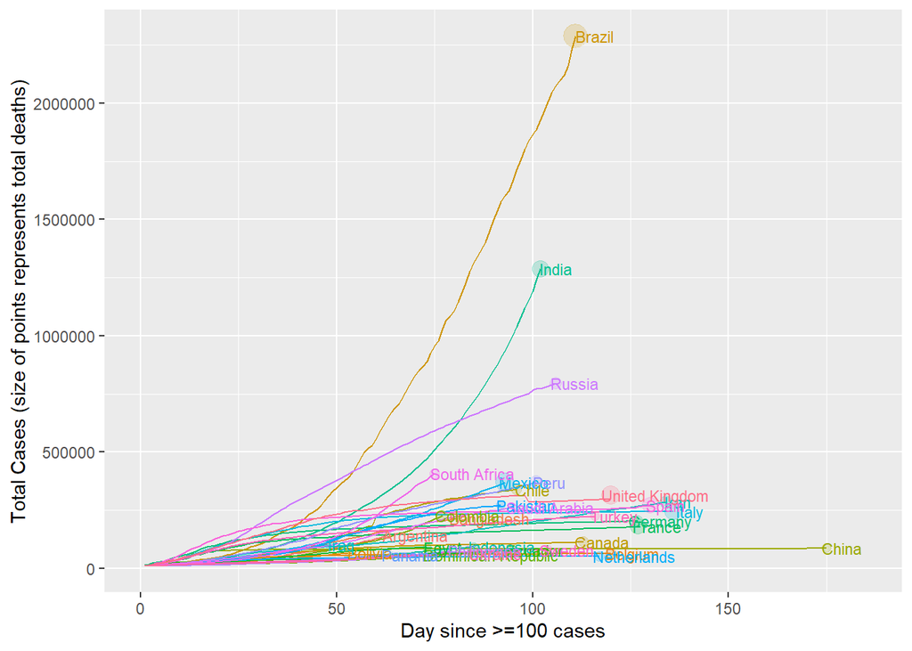

```r
DF_num_country <- DF_num %>%
  group_by(CountryExp) %>%
  summarise(Day=max(Day), Total=max(Total), TotalDeath =max(TotalDeath)) %>%
  filter(TotalDeath >= 1000)


ggplot(DF_num %>% inner_join(DF_num_country[,"CountryExp"]), aes(Day, Total, group=CountryExp, col=CountryExp)) +
  geom_line() +
  geom_point(data=DF_num_country, aes(Day,Total,size=TotalDeath), alpha=0.2) +
  geom_text(data=DF_num_country, aes(x=Day+0.8*nchar(CountryExp),y=Total,label=CountryExp),size=3) +
  theme(legend.position="none")+ xlim(0,max(DF_num_country$Day)+10) + labs(x="Day since >=100 cases",y="Total Cases (size of points represents total deaths)")
```

##Define 2 Gompertz abcd / bcd (with a=0) and Baranyi 94 Model with Self Start function

```r
SSgompertzabcd <- function (time, a, b, c, d) {
  partEq_ <- exp(1 + c*exp(1)*(b - time)/(d - a))
  partEq <- exp(-partEq_)
  partGrad <- (d - a) * (partEq * (partEq_ * (c*exp(1)*(b - time)/(d - a)^2)))
  val <- a + (d - a) * partEq
  .grad <- array(0, c(length(val), 4), list(NULL, c("a", "b", "c", "d")))
  .grad[, "a"] <- 1 - (partGrad + partEq)
  .grad[, "b"] <- -((d - a) * (partEq * (partEq_ * (c * exp(1)/(d - a)))))
  .grad[, "c"] <- -((d - a) * (partEq * (partEq_ * (exp(1) * (b - time)/(d - a)))))
  .grad[, "d"] <- partEq + partGrad
  attr(val, "gradient") <- .grad
  val
}

attributes(SSgompertzabcd)$initial <- function (mCall, data, LHS){
  sXY <- sortedXyData(mCall[["time"]], LHS, data)
  if(nrow(sXY) < 5) stop("Too few distinct input values to fit the Gompertz model")
  y0 <- NLSstLfAsymptote(sXY)
  ymax <- NLSstRtAsymptote(sXY)
  # rate is a positive value in the direction of change
  grad <- diff(sXY$y, 1)/diff(sXY$x, 1)
  rate <- max(grad)
  xpos <- which(grad == rate)[1]
  lag <- mean(sXY$x[c(xpos-2, xpos + 2)]) - (mean(sXY$y[c(xpos-2, xpos + 2)]) - y0)/rate
  if(!is.finite(lag)) lag <- 0
  val <- c(max(y0,0.1), lag, rate, ymax)
  names(val) <- mCall[c("a", "b", "c", "d")]
  val
}

attributes(SSgompertzabcd)$pnames <- c("a","b","c","d")
attributes(SSgompertzabcd)$class <- "selfStart"

SSgompertzbcd <- function (time, b, c, d) {
  a <- 0
  partEq_ <- exp(1 + c*exp(1)*(b - time)/(d - a))
  partEq <- exp(-partEq_)
  partGrad <- (d - a) * (partEq * (partEq_ * (c*exp(1)*(b - time)/(d - a)^2)))
  val <- a + (d - a) * partEq
  .grad <- array(0, c(length(val), 3), list(NULL, c("b", "c", "d")))
  .grad[, "b"] <- -((d - a) * (partEq * (partEq_ * (c * exp(1)/(d - a)))))
  .grad[, "c"] <- -((d - a) * (partEq * (partEq_ * (exp(1) * (b - time)/(d - a)))))
  .grad[, "d"] <- partEq + partGrad
  attr(val, "gradient") <- .grad
  val
}

attributes(SSgompertzbcd)$initial <- function (mCall, data, LHS){
  sXY <- sortedXyData(mCall[["time"]], LHS, data)
  if (nrow(sXY) < 5) stop("Too few distinct input values to fit the Gompertz model")
  y0 <- 0
  ymax <- NLSstRtAsymptote(sXY)
  # rate is a positive value in the direction of change
  grad <- diff(sXY$y, 2)/diff(sXY$x, 2)
  rate <- max(grad)
  xpos <- which(grad == rate)[1]
  lag <- mean(sXY$x[c(xpos, xpos + 2)]) - (mean(sXY$y[c(xpos, xpos + 2)]) - y0)/rate
  if(!is.finite(lag)) lag <- 0
  val <- c(lag, rate, max(ymax,sXY$y))
  names(val) <- mCall[c("b", "c", "d")]
  val
}

attributes(SSgompertzbcd)$pnames <- c("b","c","d")
attributes(SSgompertzbcd)$class <- "selfStart"

SSbaranyi <- function (Time, y0, ymax, mu, lambda, m = 1, v = mu)
{
  q0 <- 1/(exp(mu * lambda) - 1)
  A <- Time + log((exp(-mu * Time) + q0)/(1 + q0))/mu
  y <- ymax - log(1 + (exp((ymax - y0)) - 1)/exp(mu * A))
  y
}

attributes(SSbaranyi)$initial <- function (mCall, data, LHS){
  sXY <- sortedXyData(mCall[["time"]], LHS, data)
  if(nrow(sXY) < 5) stop("Too few distinct input values to fit the baranyi model")
  val_ <- getInitial(y ~ SSgompertzabcd(x, a,b,c,d), sXY)
  val <-val_[c(1,4,3,2)]
  names(val) <- mCall[c("y0", "ymax", "mu", "lambda")]
  val
}
attributes(SSbaranyi)$pnames <- c("y0", "ymax", "mu", "lambda")
attributes(SSbaranyi)$class <- "selfStart"
```

Function (covid_NLS_Graph) Return Selected Data, NLS model for total cases/deaths, and chart

```r
covid_NLS_Graph <- function(DF, countryName=NA, predictDays=100){
  require(dplyr)
  require(ggplot2)
  require(egg)

  if(length(countryName)==0||is.na(countryName)||countryName=="all"){
    DF_country <- DF %>%
      group_by(DateRep) %>%
      summarise(NewConfCases=sum(NewConfCases),
                NewDeaths=sum(NewDeaths)) %>% mutate(CountryExp="All")
  } else {
    DF_country <- DF %>%
      filter(tolower(CountryExp) %in% tolower(countryName)) %>%
      arrange(DateRep)
  }

  DF_country_new <- DF_country %>% filter(DateRep == max(DateRep))

  DF_country <- as.data.frame(DF_country %>%
                                mutate(Total = cumsum(NewConfCases),
                                       TotalDeath = cumsum(NewDeaths),
                                       DateDiff = as.Date(DateRep) - lag(as.Date(DateRep))) %>% filter(Total>0) %>% mutate(Day = cumsum(coalesce(as.integer(DateDiff),0L))))

  print(tail(DF_country[,c("DateRep","Day","CountryExp","NewConfCases","NewDeaths","Total","TotalDeath")]))

  logFit <- FALSE
  logDeathFit <- FALSE

  #############################################

  chkSF <- function(model){
    if(class(model)=="nls"){
      if(sum(summary(model)$parameters[2:nrow(summary(model)$parameters),4] > 0.1)>=1) {
        returnClass <- "try-error"
      } else returnClass <- "nls"
    } else {
      returnClass <- "try-error"
    }
    returnClass
  }

  ## first try 3 models
  virus_fit <-try(nls(Total ~ SSgompertzabcd(Day, a, b, c, d), data=DF_country ), TRUE)
  class(virus_fit) <- chkSF(virus_fit)

  if(class(virus_fit)=="try-error"){
    virus_fit <-try(nls(Total ~ SSbaranyi(Day, y0, ymax, mu, lambda), data=DF_country ), TRUE)
    class(virus_fit) <- chkSF(virus_fit)
  }

  if(class(virus_fit)=="try-error"){
    virus_fit <-try(nls(Total ~ SSgompertzbcd(Day, b, c, d), data=DF_country ), TRUE)
    class(virus_fit) <- chkSF(virus_fit)
  }

  if(class(virus_fit)=="try-error"){
    for(i in (nrow(DF_country)-1):(nrow(DF_country)-5)){
      if(class(virus_fit)=="try-error"){
        virus_fit <-try(nls(Total ~ SSgompertzabcd(Day, a, b, c, d), data=DF_country[-(i:(nrow(DF_country)-1)),] ), TRUE)
        class(virus_fit) <- chkSF(virus_fit)

        if(class(virus_fit)=="try-error"){
          virus_fit <-try(nls(Total ~ SSbaranyi(Day, y0, ymax, mu, lambda), data=DF_country[-(i:(nrow(DF_country)-1)),] ), TRUE)
          class(virus_fit) <- chkSF(virus_fit)
        }

        if(class(virus_fit)=="try-error"){
          virus_fit <-try(nls(Total ~ SSgompertzbcd(Day, b, c, d), data=DF_country[-(i:(nrow(DF_country)-1)),] ), TRUE)
          class(virus_fit) <- chkSF(virus_fit)
        }

        if(class(virus_fit)=="nls") cat(paste0("total case take out ",paste(i:nrow(DF_country),collapse=",")))
      }
    }
  }

  if(class(virus_fit)=="nls") Fit <- predict(virus_fit,newdata=data.frame(Day=1:predictDays))

  if(class(virus_fit)=="try-error"){
    virus_fit <-try(nls(I(log(Total+1)) ~ SSgompertzabcd(Day, a, b, c, d), data=DF_country ), TRUE)
    class(virus_fit) <- chkSF(virus_fit)

    if(class(virus_fit)=="try-error"){
      virus_fit <-try(nls(I(log(Total+1)) ~ SSbaranyi(Day, y0, ymax, mu, lambda), data=DF_country ), TRUE)
      class(virus_fit) <- chkSF(virus_fit)
    }

    if(class(virus_fit)=="try-error"){
      virus_fit <-try(nls(I(log(Total+1)) ~ SSgompertzbcd(Day, b, c, d), data=DF_country ), TRUE)
      class(virus_fit) <- chkSF(virus_fit)
    }

    if(class(virus_fit)=="try-error"){
      for(i in (nrow(DF_country)-1):(nrow(DF_country)-5)){
        if(class(virus_fit)=="try-error"){
          virus_fit <-try(nls(I(log(Total+1)) ~ SSgompertzabcd(Day, a, b, c, d), data=DF_country[-(i:(nrow(DF_country)-1)),] ), TRUE)
          class(virus_fit) <- chkSF(virus_fit)

          if(class(virus_fit)=="try-error"){
            virus_fit <-try(nls(I(log(Total+1)) ~ SSbaranyi(Day, y0, ymax, mu, lambda), data=DF_country[-(i:(nrow(DF_country)-1)),] ), TRUE)
            class(virus_fit) <- chkSF(virus_fit)
          }

          if(class(virus_fit)=="try-error"){
            virus_fit <-try(nls(I(log(Total+1)) ~ SSgompertzbcd(Day, b, c, d), data=DF_country[-(i:(nrow(DF_country)-1)),] ), TRUE)
            class(virus_fit) <- chkSF(virus_fit)
          }
          if(class(virus_fit)=="nls") cat(paste0("log(total case + 1) take out ",paste(i:nrow(DF_country),collapse=",")))
        }
      }
    }
    if(class(virus_fit)=="nls") {
      Fit <- exp(predict(virus_fit,newdata=data.frame(Day=1:predictDays)))
      logFit <- TRUE
    }
  }


  ############################################

  death_fit <-try(nls(TotalDeath ~ SSgompertzabcd(Day, a, b, c, d), data=DF_country ), TRUE)
  class(death_fit) <- chkSF(death_fit)

  if(class(death_fit)=="try-error"){
    death_fit <-try(nls(TotalDeath ~ SSgompertzbcd(Day, b, c, d), data=DF_country ), TRUE)
    class(death_fit) <- chkSF(death_fit)
  }

  if(class(death_fit)=="try-error"){
    for(i in (nrow(DF_country)-1):(nrow(DF_country)-5)){
      if(class(death_fit)=="try-error"){
        death_fit <-try(nls(TotalDeath ~ SSgompertzabcd(Day, a, b, c, d), data=DF_country[-(i:(nrow(DF_country)-1)),] ), TRUE)
        class(death_fit) <- chkSF(death_fit)

        if(class(death_fit)=="try-error"){
          death_fit <-try(nls(TotalDeath ~ SSgompertzbcd(Day, b, c, d), data=DF_country[-(i:(nrow(DF_country)-1)),] ), TRUE)
          class(death_fit) <- chkSF(death_fit)
        }
        if(class(death_fit)=="nls") cat(paste0("total death take out rows: ",paste(i:(nrow(DF_country)-1),collapse=",")))
      }
    }
  }

  if(class(death_fit)=="nls") Fit_Death <- predict(death_fit,newdata=data.frame(Day=1:predictDays))

  if(class(death_fit)=="try-error"){
    death_fit <-try(nls(I(log(TotalDeath+1)) ~ SSgompertzabcd(Day, a, b, c, d), data=DF_country ), TRUE)
    class(death_fit) <- chkSF(death_fit)

    if(class(death_fit)=="try-error"){
      death_fit <-try(nls(I(log(TotalDeath+1)) ~ SSgompertzbcd(Day, b, c, d), data=DF_country ), TRUE)
      class(death_fit) <- chkSF(death_fit)
    }

    if(class(death_fit)=="try-error"){
      for(i in (nrow(DF_country)-1):(nrow(DF_country)-5)){
        if(class(death_fit)=="try-error"){
          death_fit <-try(nls(I(log(TotalDeath+1)) ~ SSgompertzabcd(Day, a, b, c, d), data=DF_country[-(i:(nrow(DF_country)-1)),] ), TRUE)
          class(death_fit) <- chkSF(death_fit)

          if(class(death_fit)=="try-error"){
            death_fit <-try(nls(I(log(TotalDeath+1)) ~ SSgompertzbcd(Day, b, c, d), data=DF_country[-(i:(nrow(DF_country)-1)),] ), TRUE)
            class(death_fit) <- chkSF(death_fit)
          }
          if(class(death_fit)=="nls") cat(paste0("log(total death + 1) take out rows: ",paste(i:(nrow(DF_country)-1),collapse=",")))
        }
      }
    }
    if(class(death_fit)=="nls") {
      Fit_Death <- exp(predict(death_fit,newdata=data.frame(Day=1:predictDays)))
      logDeathFit <- TRUE
    }
  }

  ############################################


  gphTotal <- ggplot(DF_country, aes(Day, Total)) +
    geom_point(col="blue", size=3)  +
    labs(title=paste0(countryName, " Covid-19 Overall Cumulative Cases & Deaths"),
         x=paste0("Day from ",as.Date(min(DF_country$DateRep))))+
    theme(plot.title = element_text(size=16))

  gphDeath <- ggplot(DF_country, aes(Day, TotalDeath)) +
    geom_point(col="green", size=3)  +
    labs(title="",
         x=paste0("Day from ",as.Date(min(DF_country$DateRep))))+
    theme(plot.title = element_text(size=16))


  if(class(virus_fit)!="try-error")  {
    gphTotal <- gphTotal +
                   geom_line(data=data.frame(Day=1:predictDays,Fit=Fit),
                     mapping=aes(Day,Fit),col="red", size=1) +
                   labs(subtitle= paste0("Predicted on ",as.Date(max(DF_country$DateRep))))

    DF_country$FitTotal <- ifelse(logFit, exp(predict(virus_fit,newdata=DF_country)), predict(virus_fit,newdata=DF_country))

    if(logFit) cat("Total cases transformed to log (base e) \n")
  } else {
    gphTotal <- gphTotal + labs(subtitle= paste0("Updated on ",as.Date(max(DF_country$DateRep))))
  }

  if(class(death_fit)!="try-error")  {
    gphDeath <- gphDeath +
      geom_line(data=data.frame(Day=1:predictDays,Fit=Fit_Death),
                mapping=aes(Day,Fit_Death),col="red", size=1) +
      labs(subtitle= paste0("Predicted on ",as.Date(max(DF_country$DateRep))))

    DF_country$FitDeath <- ifelse(logDeathFit, exp(predict(death_fit,newdata=DF_country)), predict(death_fit,newdata=DF_country))

    if(logDeathFit) cat("Total Death transformed to log (base e) \n")
  } else {
    gphDeath <- gphDeath + labs(subtitle= paste0("Updated on ",as.Date(max(DF_country$DateRep))))
  }

  return(list(data = DF_country,
              modelTotal = virus_fit,
              modelDeath = death_fit,
              graphTotal = gphTotal,
              graphDeath = gphDeath))
}
```

## NLS Model Result for UK

Note that when you know that some governments are not going to test it and report it, it really doesn’t matter what the model is like …

```r
if(class(covid_19$modelTotal)!="try-error")  {
  print(summary(covid_19$modelTotal))
} else {
  print("Algorithm is not converge for modelling total cases")
}
```

```
##
## Formula: Total ~ SSgompertzabcd(Day, a, b, c, d)
##
## Parameters:
##    Estimate Std. Error t value Pr(>|t|)
## a 2.820e+02  8.136e+02   0.347    0.729
## b 6.033e+01  3.968e-01 152.049   <2e-16 ***
## c 5.711e+03  7.406e+01  77.120   <2e-16 ***
## d 3.046e+05  1.138e+03 267.761   <2e-16 ***
## ---
## Signif. codes:  0 '***' 0.001 '**' 0.01 '*' 0.05 '.' 0.1 ' ' 1
##
## Residual standard error: 5873 on 172 degrees of freedom
##
## Number of iterations to convergence: 6
## Achieved convergence tolerance: 1.155e-06
```

```r
if(class(covid_19$modelDeath)!="try-error")  {
  print(summary(covid_19$modelDeath))
} else {
  print("Algorithm is not converge for modelling total deaths")
}
```

```
##
## Formula: TotalDeath ~ SSgompertzabcd(Day, a, b, c, d)
##
## Parameters:
##    Estimate Std. Error t value Pr(>|t|)
## a  -252.807     96.759  -2.613  0.00978 **
## b    59.082      0.325 181.810  < 2e-16 ***
## c   810.480      8.229  98.493  < 2e-16 ***
## d 44789.598    137.656 325.373  < 2e-16 ***
## ---
## Signif. codes:  0 '***' 0.001 '**' 0.01 '*' 0.05 '.' 0.1 ' ' 1
##
## Residual standard error: 687.3 on 172 degrees of freedom
##
## Number of iterations to convergence: 6
## Achieved convergence tolerance: 2.338e-06
```

If the algorithm is not able to converge after some trying, the function will just show the graph with count

## Country Data

```r
OutputData <- covid_19$data %>%
               select(DateRep, Day, CountryExp, NewConfCases, NewDeaths,
                      Total, TotalDeath) %>%
               arrange(desc(Day))
print(head(OutputData,10))
```

```
##       DateRep Day     CountryExp NewConfCases NewDeaths  Total TotalDeath
## 1  2020-07-24 176 United Kingdom          769        53 297146      45554
## 2  2020-07-23 175 United Kingdom          560        79 296377      45501
## 3  2020-07-22 174 United Kingdom          445       110 295817      45422
## 4  2020-07-21 173 United Kingdom          580        12 295372      45312
## 5  2020-07-20 172 United Kingdom          726        27 294792      45300
## 6  2020-07-19 171 United Kingdom          827        40 294066      45273
## 7  2020-07-18 170 United Kingdom          687       114 293239      45233
## 8  2020-07-17 169 United Kingdom          641        66 292552      45119
## 9  2020-07-16 168 United Kingdom          538        85 291911      45053
## 10 2020-07-15 167 United Kingdom         1240       138 291373      44968
```

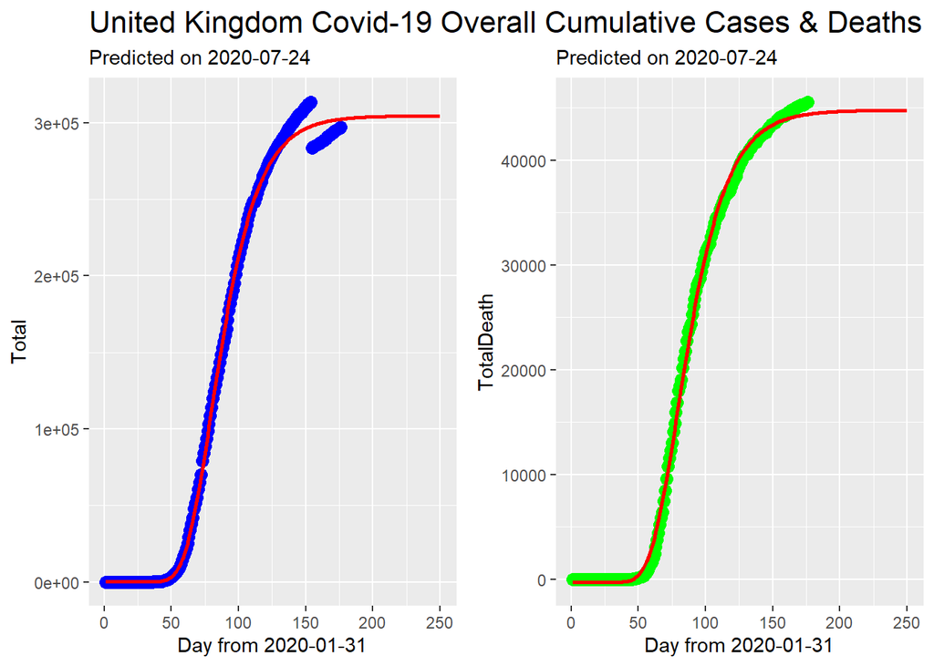

```r
ggarrange(covid_19$graphTotal, covid_19$graphDeath, ncol=2)
```

Note that, this exercise is just simple way of looking at the problem, and it’s rather like a starting point. The algorithm with the self starting function in nls is the first way to go, but there are much more after this. In the function, a is the left asymptote, b is the lag time, i.e. the time to grow, c is the growth rate, and d is the right asymptote. b, c, d should be modelled as well, and combine into one, with other factors like age, sex, other complication, population density, propotion of people wearing mask, population that is travelling during pandemic, etc… However, if a lot of cases are not tested, the number is not correct, this can be reflected from the death rate.

## USA

```r
usa <- covid_NLS_Graph(DF,
                 countryName="United States Of America",
                 predictDays=250)
```

```
##        DateRep Day               CountryExp NewConfCases NewDeaths   Total
## 181 2020-07-19 181 United States Of America        63749       853 3711464
## 182 2020-07-20 182 United States Of America        61796       415 3773260
## 183 2020-07-21 183 United States Of America        56750       372 3830010
## 184 2020-07-22 184 United States Of America        72048      1160 3902058
## 185 2020-07-23 185 United States Of America        68848      1124 3970906
## 186 2020-07-24 186 United States Of America        63196      1052 4034102
##     TotalDeath
## 181     140119
## 182     140534
## 183     140906
## 184     142066
## 185     143190
## 186     144242
```

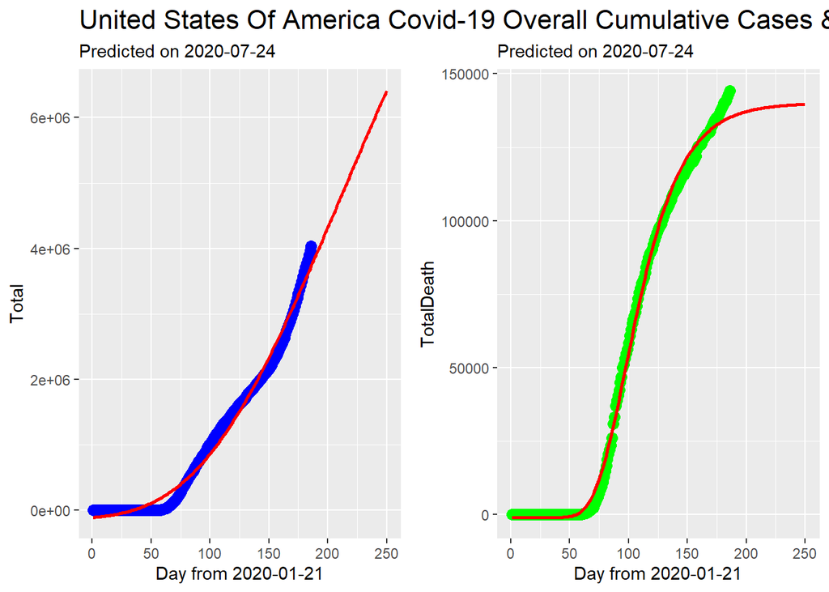

```r
ggarrange(usa$graphTotal, usa$graphDeath, ncol=2)
```

```r
print(usa$modelTotal)
```

```
## Nonlinear regression model
##   model: Total ~ SSgompertzabcd(Day, a, b, c, d)
##    data: DF_country
##          a          b          c          d
## -1.405e+05  9.479e+01  4.237e+04  1.333e+07
##  residual sum-of-squares: 3.084e+12
##
## Number of iterations to convergence: 9
## Achieved convergence tolerance: 6.794e-06
```

```r
print(usa$modelDeath)
```

```
## Nonlinear regression model
##   model: TotalDeath ~ SSgompertzabcd(Day, a, b, c, d)
##    data: DF_country
##         a         b         c         d
##   -910.98     71.54   1962.52 140103.93
##  residual sum-of-squares: 1.535e+09
##
## Number of iterations to convergence: 9
## Achieved convergence tolerance: 1.96e-06
```

## Italy

```r
italy <- covid_NLS_Graph(DF,
                 countryName="Italy",
                 predictDays=250)
```

```
##        DateRep Day CountryExp NewConfCases NewDeaths  Total TotalDeath
## 171 2020-07-19 171      Italy          249        14 244216      35042
## 172 2020-07-20 172      Italy          218         3 244434      35045
## 173 2020-07-21 173      Italy          190        13 244624      35058
## 174 2020-07-22 174      Italy          128        15 244752      35073
## 175 2020-07-23 175      Italy          280         9 245032      35082
## 176 2020-07-24 176      Italy          306        10 245338      35092
```

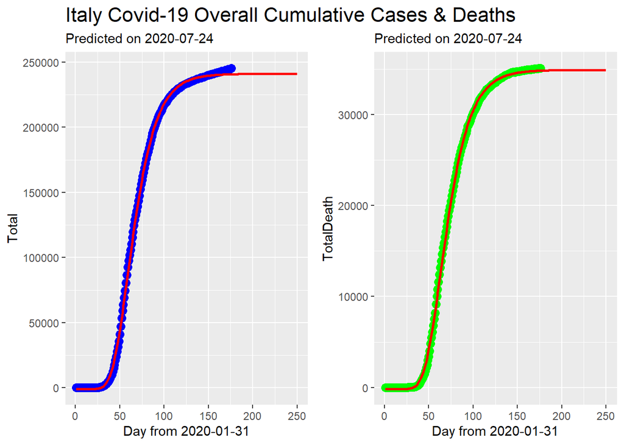

```r
ggarrange(italy$graphTotal, italy$graphDeath, ncol=2)
```

```r
print(italy$modelTotal)
```

```
## Nonlinear regression model
##   model: Total ~ SSgompertzabcd(Day, a, b, c, d)
##    data: DF_country
##         a         b         c         d
##   -911.90     41.43   5019.06 241077.67
##  residual sum-of-squares: 7.02e+08
##
## Number of iterations to convergence: 5
## Achieved convergence tolerance: 6.159e-06
```

```r
print(italy$modelDeath)
```

```
## Nonlinear regression model
##   model: TotalDeath ~ SSgompertzabcd(Day, a, b, c, d)
##    data: DF_country
##        a        b        c        d
##  -159.51    45.12   704.42 34902.79
##  residual sum-of-squares: 14787887
##
## Number of iterations to convergence: 6
## Achieved convergence tolerance: 9.479e-07
```

## Spain

```r
spain <- covid_NLS_Graph(DF,
                 countryName="Spain",
                 predictDays=250)
```

```
##        DateRep Day CountryExp NewConfCases NewDeaths  Total TotalDeath
## 169 2020-07-18 169      Spain            0         0 260255      28420
## 170 2020-07-19 170      Spain            0         0 260255      28420
## 171 2020-07-20 171      Spain         4581         2 264836      28422
## 172 2020-07-21 172      Spain         1358         2 266194      28424
## 173 2020-07-22 173      Spain         1357         2 267551      28426
## 174 2020-07-23 174      Spain         2615         3 270166      28429
```

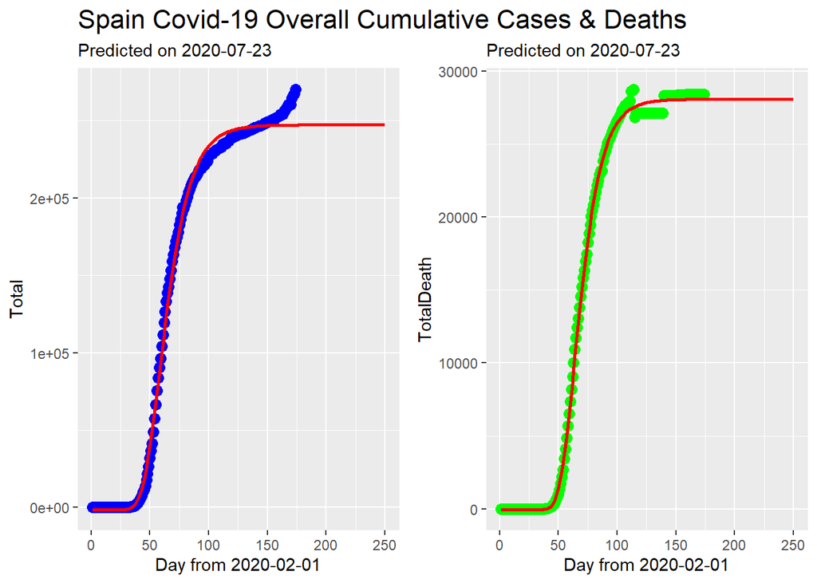

```r
ggarrange(spain$graphTotal, spain$graphDeath, ncol=2)
```

```r
print(spain$modelTotal)
```

```
## Nonlinear regression model
##   model: Total ~ SSgompertzabcd(Day, a, b, c, d)
##    data: DF_country
##         a         b         c         d
##  -1385.82     44.05   6320.13 247250.43
##  residual sum-of-squares: 6.153e+09
##
## Number of iterations to convergence: 6
## Achieved convergence tolerance: 6.846e-06
```

```r
print(spain$modelDeath)
```

```
## Nonlinear regression model
##   model: TotalDeath ~ SSgompertzabcd(Day, a, b, c, d)
##    data: DF_country
##        a        b        c        d
##   -47.31    51.12   807.77 28079.48
##  residual sum-of-squares: 28073575
##
## Number of iterations to convergence: 12
## Achieved convergence tolerance: 4.526e-07
```

## Germany

```r
germany <- covid_NLS_Graph(DF,
                 countryName="Germany",
                 predictDays=250)
```

```
##        DateRep Day CountryExp NewConfCases NewDeaths  Total TotalDeath
## 174 2020-07-19 174    Germany          202         1 201574       9084
## 175 2020-07-20 175    Germany          249         2 201823       9086
## 176 2020-07-21 176    Germany          522         4 202345       9090
## 177 2020-07-22 177    Germany          454         5 202799       9095
## 178 2020-07-23 178    Germany          569         6 203368       9101
## 179 2020-07-24 179    Germany          815        10 204183       9111
```

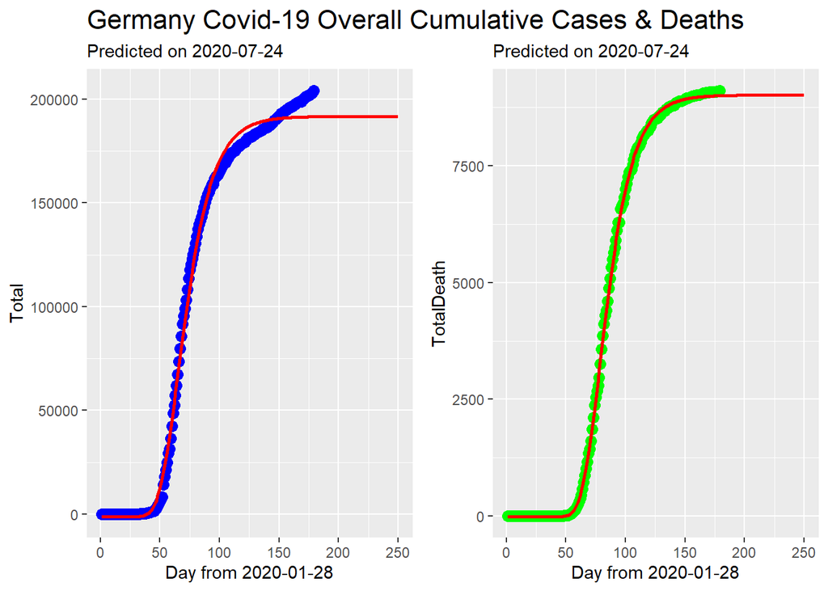

```r
ggarrange(germany$graphTotal, germany$graphDeath, ncol=2)
```

```r
print(germany$modelTotal)
```

```
## Nonlinear regression model
##   model: Total ~ SSgompertzabcd(Day, a, b, c, d)
##    data: DF_country
##         a         b         c         d
##  -1186.04     49.57   4415.89 191765.56
##  residual sum-of-squares: 4.165e+09
##
## Number of iterations to convergence: 7
## Achieved convergence tolerance: 2.294e-06
```

```r
print(germany$modelDeath)
```

```
## Nonlinear regression model
##   model: TotalDeath ~ SSgompertzabcd(Day, a, b, c, d)
##    data: DF_country
##        a        b        c        d
##   -8.808   63.395  214.814 9016.641
##  residual sum-of-squares: 553878
##
## Number of iterations to convergence: 5
## Achieved convergence tolerance: 3.876e-06
```

## France

```r
france <- covid_NLS_Graph(DF,
                 countryName="France",
                 predictDays=250)
```

```
##        DateRep Day CountryExp NewConfCases NewDeaths  Total TotalDeath
## 177 2020-07-19 177     France            0         0 174674      30152
## 178 2020-07-20 178     France            0         0 174674      30152
## 179 2020-07-21 179     France         2080        13 176754      30165
## 180 2020-07-22 180     France          584         0 177338      30165
## 181 2020-07-23 181     France          998         7 178336      30172
## 182 2020-07-24 182     France         1062        10 179398      30182
```

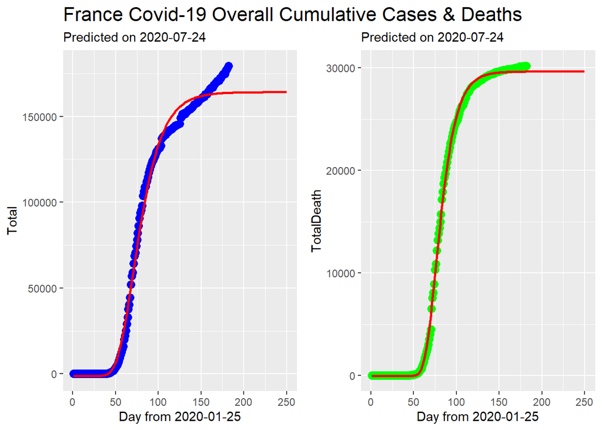

```r
ggarrange(france$graphTotal, france$graphDeath, ncol=2)
```

```r
print(france$modelTotal)
```

```
## Nonlinear regression model
##   model: Total ~ SSgompertzabcd(Day, a, b, c, d)
##    data: DF_country
##        a        b        c        d
##  -1170.4     52.2   3278.3 164160.1
##  residual sum-of-squares: 5.041e+09
##
## Number of iterations to convergence: 9
## Achieved convergence tolerance: 7.789e-06
```

```r
print(france$modelDeath)
```

```
## Nonlinear regression model
##   model: TotalDeath ~ SSgompertzabcd(Day, a, b, c, d)
##    data: DF_country
##        a        b        c        d
##   -31.22    63.17   837.72 29643.33
##  residual sum-of-squares: 23734440
##
## Number of iterations to convergence: 7
## Achieved convergence tolerance: 4.879e-06
```

## Brazil

```r
brazil <- covid_NLS_Graph(DF,
                 countryName="Brazil",
                 predictDays=500)
```

```
##        DateRep Day CountryExp NewConfCases NewDeaths   Total TotalDeath
## 145 2020-07-19 145     Brazil        28532       921 2074860      78772
## 146 2020-07-20 146     Brazil        23529       716 2098389      79488
## 147 2020-07-21 147     Brazil        20257       632 2118646      80120
## 148 2020-07-22 148     Brazil        41008      1367 2159654      81487
## 149 2020-07-23 149     Brazil        67860      1284 2227514      82771
## 150 2020-07-24 150     Brazil        59961      1311 2287475      84082
```

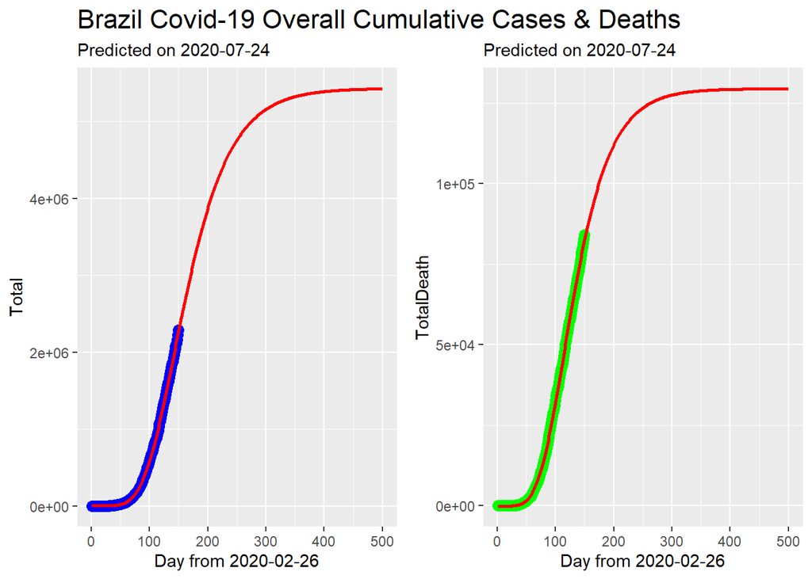

```r
ggarrange(brazil$graphTotal, brazil$graphDeath, ncol=2)
```

```r
print(brazil$modelTotal)
```

```
## Nonlinear regression model
##   model: Total ~ SSgompertzabcd(Day, a, b, c, d)
##    data: DF_country
##         a         b         c         d
## 3.202e+03 8.986e+01 3.764e+04 5.433e+06
##  residual sum-of-squares: 1.282e+10
##
## Number of iterations to convergence: 5
## Achieved convergence tolerance: 9.58e-06
```

```r
print(brazil$modelDeath)
```

```
## Nonlinear regression model
##   model: TotalDeath ~ SSgompertzabcd(Day, a, b, c, d)
##    data: DF_country
##         a         b         c         d
##   -140.75     70.68   1079.39 129508.98
##  residual sum-of-squares: 32229439
##
## Number of iterations to convergence: 5
## Achieved convergence tolerance: 2.129e-06
```

## Russia

```r
russia <- covid_NLS_Graph(DF,
                 countryName="Russia",
                 predictDays=500)
```

```
##        DateRep Day CountryExp NewConfCases NewDeaths  Total TotalDeath
## 170 2020-07-19 170     Russia         6109        95 771546      12342
## 171 2020-07-20 171     Russia            0         0 771546      12342
## 172 2020-07-21 172     Russia         5940        85 777486      12427
## 173 2020-07-22 173     Russia         5842       153 783328      12580
## 174 2020-07-23 174     Russia         5862       165 789190      12745
## 175 2020-07-24 175     Russia         5848       147 795038      12892
```

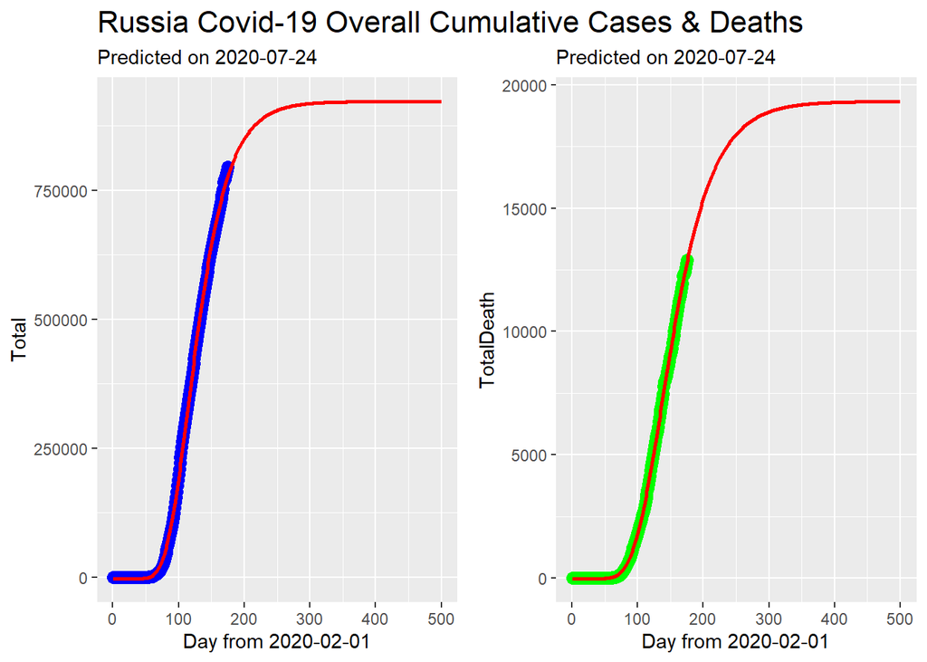

```r
ggarrange(russia$graphTotal, russia$graphDeath, ncol=2)
```

```r
print(russia$modelTotal)
```

```
## Nonlinear regression model
##   model: Total ~ SSgompertzabcd(Day, a, b, c, d)
##    data: DF_country
##         a         b         c         d
##  -2621.76     81.39  10039.79 922336.05
##  residual sum-of-squares: 9.606e+09
##
## Number of iterations to convergence: 7
## Achieved convergence tolerance: 8.43e-06
```

```r
print(russia$modelDeath)
```

```
## Nonlinear regression model
##   model: TotalDeath ~ SSgompertzabcd(Day, a, b, c, d)
##    data: DF_country
##        a        b        c        d
##   -19.36    94.26   166.13 19330.00
##  residual sum-of-squares: 856990
##
## Number of iterations to convergence: 6
## Achieved convergence tolerance: 4.588e-06
```

## India

```r
india <- covid_NLS_Graph(DF,
                 countryName="India",
                 predictDays=500)
```

```
##        DateRep Day CountryExp NewConfCases NewDeaths   Total TotalDeath
## 171 2020-07-19 172      India        38902       543 1077618      26816
## 172 2020-07-20 173      India        40425       681 1118043      27497
## 173 2020-07-21 174      India        37148       587 1155191      28084
## 174 2020-07-22 175      India        37724       648 1192915      28732
## 175 2020-07-23 176      India        45720      1129 1238635      29861
## 176 2020-07-24 177      India        49310       740 1287945      30601
## Total cases transformed to log (base e)
```

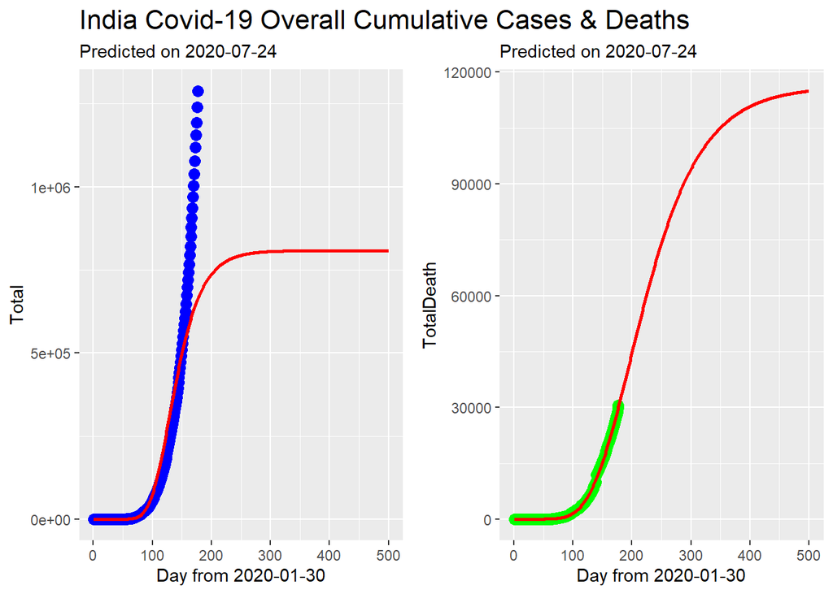

```r
ggarrange(india$graphTotal, india$graphDeath, ncol=2)
```

```r
print(india$modelTotal)
```

```
## Nonlinear regression model
##   model: I(log(Total + 1)) ~ SSgompertzabcd(Day, a, b, c, d)
##    data: DF_country
##       a       b       c       d
##  0.7532 22.6497  0.1580 13.6022
##  residual sum-of-squares: 22.62
##
## Number of iterations to convergence: 9
## Achieved convergence tolerance: 4.278e-06
```

```r
print(india$modelDeath)
```

```
## Nonlinear regression model
##   model: TotalDeath ~ SSgompertzabcd(Day, a, b, c, d)
##    data: DF_country
##         a         b         c         d
##     38.42    130.77    644.06 116117.71
##  residual sum-of-squares: 14691403
##
## Number of iterations to convergence: 10
## Achieved convergence tolerance: 3.658e-06
```

hmmm….

## All

```r
DF_all <- DF %>% group_by(DateRep) %>% summarise(NewConfCases=sum(NewConfCases), NewDeaths=sum(NewDeaths)) %>% mutate(CountryExp="All")
All_cases <- covid_NLS_Graph(DF_all, "All", predictDays = 1000)
```

```
##        DateRep Day CountryExp NewConfCases NewDeaths    Total TotalDeath
## 202 2020-07-19 201        All       228575      4891 14269303     602047
## 203 2020-07-20 202        All       212143      3945 14481446     605992
## 204 2020-07-21 203        All       201345      4108 14682791     610100
## 205 2020-07-22 204        All       239411      6219 14922202     616319
## 206 2020-07-23 205        All       281951      6966 15204153     623285
## 207 2020-07-24 206        All       273319      9837 15477472     633122
```

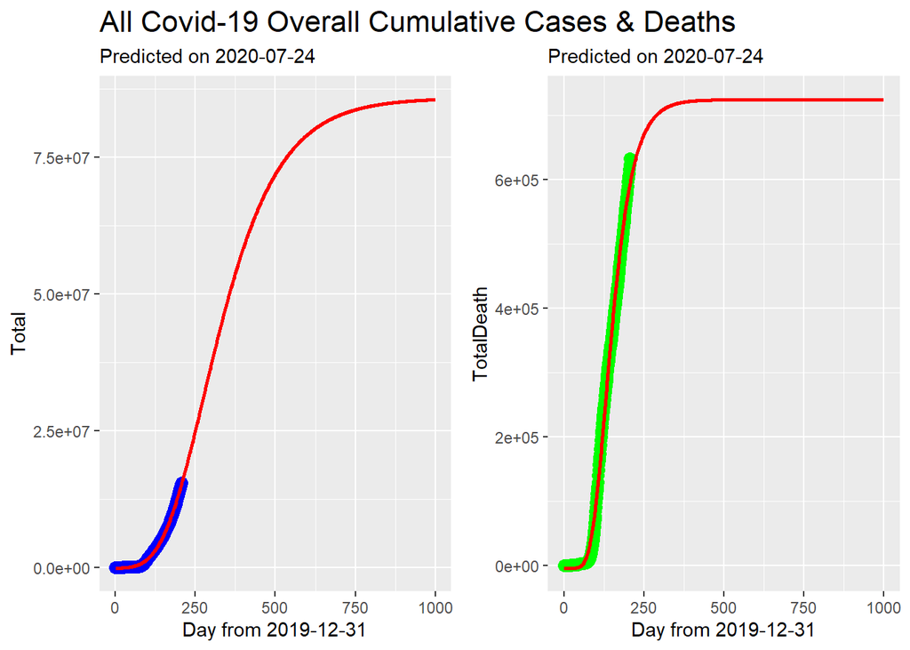

```r
ggarrange(All_cases$graphTotal, All_cases$graphDeath, ncol=2)
```

```r
print(All_cases$modelTotal)
```

```
## Nonlinear regression model
##   model: Total ~ SSgompertzabcd(Day, a, b, c, d)
##    data: DF_country
##          a          b          c          d
##  -181116.6      147.9   245679.2 85882696.5
##  residual sum-of-squares: 8.793e+12
##
## Number of iterations to convergence: 8
## Achieved convergence tolerance: 6.566e-06
```

```r
print(All_cases$modelDeath)
```

```
## Nonlinear regression model
##   model: TotalDeath ~ SSgompertzabcd(Day, a, b, c, d)
##    data: DF_country
##         a         b         c         d
##  -4564.21     85.14   5793.59 724770.64
##  residual sum-of-squares: 3.956e+10
##
## Number of iterations to convergence: 8
## Achieved convergence tolerance: 1.815e-06
```

## All but China

```r
DF_all_exclude_China <- DF %>% filter(CountryExp != "China") %>% group_by(DateRep) %>% summarise(NewConfCases=sum(NewConfCases), NewDeaths=sum(NewDeaths)) %>% mutate(CountryExp="All but China")
All_but_china <- covid_NLS_Graph(DF_all_exclude_China, "All but China", predictDays = 1000)
```

```
##        DateRep Day    CountryExp NewConfCases NewDeaths    Total TotalDeath
## 189 2020-07-19 189 All but China       228495      4890 14183820     597401
## 190 2020-07-20 190 All but China       212013      3945 14395833     601346
## 191 2020-07-21 191 All but China       201261      4108 14597094     605454
## 192 2020-07-22 192 All but China       239337      6217 14836431     611671
## 193 2020-07-23 193 All but China       281816      6966 15118247     618637
## 194 2020-07-24 194 All but China       273180      9836 15391427     628473
```

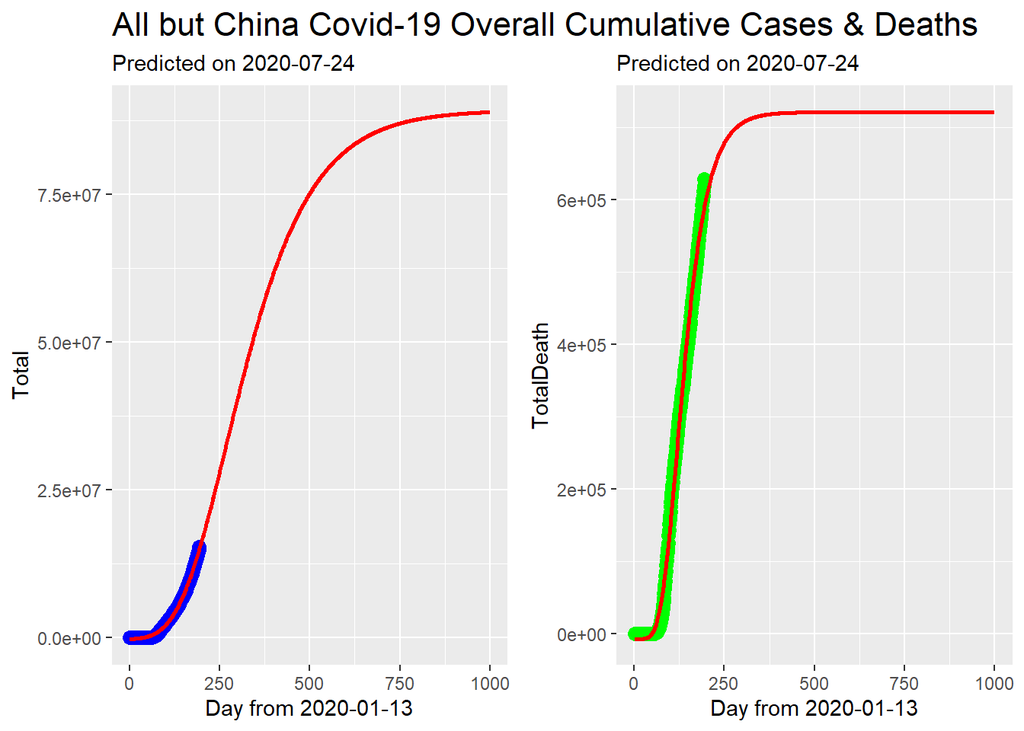

```r
ggarrange(All_but_china$graphTotal, All_but_china$graphDeath, ncol=2)
```

```r
print(All_but_china$modelTotal)
```

```
## Nonlinear regression model
##   model: Total ~ SSgompertzabcd(Day, a, b, c, d)
##    data: DF_country
##          a          b          c          d
##  -269751.1      137.8   251172.9 89236106.9
##  residual sum-of-squares: 9.036e+12
##
## Number of iterations to convergence: 9
## Achieved convergence tolerance: 1.759e-06
```

```r
print(All_but_china$modelDeath)
```

```
## Nonlinear regression model
##   model: TotalDeath ~ SSgompertzabcd(Day, a, b, c, d)
##    data: DF_country
##         a         b         c         d
##  -6860.11     73.41   5777.82 720926.84
##  residual sum-of-squares: 3.973e+10
##
## Number of iterations to convergence: 8
## Achieved convergence tolerance: 4.041e-06
```

The equation only work if the environment stay constant, but in reality, they should be an equation of time too. This is too much of data and time beyond the model here.